# A15- Student Performance Data Set

Panagiotis Symianakis

04/01/2022

## Appendix

### Athens University of Economics and Bussines

[figure not shown]

### M.Sc. in Statistics

First of all, we input the given data set to our environment in R.

```r
library(readr)
student_por <- read_delim("C:/Users/Πάνος/Desktop/stat.aueb/Advanced Data Analysis/Assignment 1/student-por.csv",delim = ";", escape_double = FALSE, trim_ws = TRUE)
student<-data.frame(student_por)
head(student)
```

```
##   school sex age address famsize Pstatus Medu Fedu     Mjob     Fjob     reason
## 1     GP   F  18       U     GT3       A    4    4  at_home  teacher     course
## 2     GP   F  17       U     GT3       T    1    1  at_home    other     course
## 3     GP   F  15       U     LE3       T    1    1  at_home    other      other
## 4     GP   F  15       U     GT3       T    4    2   health services       home
## 5     GP   F  16       U     GT3       T    3    3    other    other       home
## 6     GP   M  16       U     LE3       T    4    3 services    other reputation
##   guardian traveltime studytime failures schoolsup famsup paid activities
## 1   mother          2         2        0       yes     no   no         no
## 2   father          1         2        0        no    yes   no         no
## 3   mother          1         2        0       yes     no   no         no
## 4   mother          1         3        0        no    yes   no        yes
## 5   father          1         2        0        no    yes   no         no
## 6   mother          1         2        0        no    yes   no        yes
##   nursery higher internet romantic famrel freetime goout Dalc Walc health
## 1     yes    yes       no       no      4        3     4    1    1      3
## 2      no    yes      yes       no      5        3     3    1    1      3
## 3     yes    yes      yes       no      4        3     2    2    3      3
## 4     yes    yes      yes      yes      3        2     2    1    1      5
## 5     yes    yes       no       no      4        3     2    1    2      5
## 6     yes    yes      yes       no      5        4     2    1    2      5
##   absences G1 G2 G3
## 1        4  0 11 11
## 2        2  9 11 11
## 3        6 12 13 12
## 4        0 14 14 14
## 5        0 11 13 13
## 6        6 12 12 13
```

Then we convert the data which are characters into factors.

```r
student$school<-as.factor(student$school)
student$sex<-as.factor(student$sex)
student$address<-as.factor(student$address)
student$famsize<-as.factor(student$famsize)
student$Pstatus<-as.factor(student$Pstatus)
student$Mjob<-as.factor(student$Mjob)
student$Fjob<-as.factor(student$Fjob)
student$reason<-as.factor(student$reason)
student$guardian<-as.factor(student$guardian)
student$schoolsup<-as.factor(student$schoolsup)
student$famsup<-as.factor(student$famsup)
student$paid<-as.factor(student$paid)
student$activities<-as.factor(student$activities)
student$nursery<-as.factor(student$nursery)
student$higher<-as.factor(student$higher)
student$internet<-as.factor(student$internet)
student$romantic<-as.factor(student$romantic)

summary(student)
```

```
##  school   sex          age        address famsize   Pstatus      Medu
##  GP:423   F:383   Min.   :15.00   R:197   GT3:457   A: 80   Min.   :0.000
##  MS:226   M:266   1st Qu.:16.00   U:452   LE3:192   T:569   1st Qu.:2.000
##                   Median :17.00                             Median :2.000
##                   Mean   :16.74                             Mean   :2.515
##                   3rd Qu.:18.00                             3rd Qu.:4.000
##                   Max.   :22.00                             Max.   :4.000
##       Fedu             Mjob           Fjob            reason      guardian
##  Min.   :0.000   at_home :135   at_home : 42   course    :285   father:153
##  1st Qu.:1.000   health  : 48   health  : 23   home      :149   mother:455
##  Median :2.000   other   :258   other   :367   other     : 72   other : 41
##  Mean   :2.307   services:136   services:181   reputation:143
##  3rd Qu.:3.000   teacher : 72   teacher : 36
##  Max.   :4.000
##    traveltime      studytime        failures      schoolsup famsup     paid
##  Min.   :1.000   Min.   :1.000   Min.   :0.0000   no :581   no :251   no :610
##  1st Qu.:1.000   1st Qu.:1.000   1st Qu.:0.0000   yes: 68   yes:398   yes: 39
##  Median :1.000   Median :2.000   Median :0.0000
##  Mean   :1.569   Mean   :1.931   Mean   :0.2219
##  3rd Qu.:2.000   3rd Qu.:2.000   3rd Qu.:0.0000
##  Max.   :4.000   Max.   :4.000   Max.   :3.0000
##  activities nursery   higher    internet  romantic      famrel
##  no :334    no :128   no : 69   no :151   no :410   Min.   :1.000
##  yes:315    yes:521   yes:580   yes:498   yes:239   1st Qu.:4.000
##                                                     Median :4.000
##                                                     Mean   :3.931
##                                                     3rd Qu.:5.000
##                                                     Max.   :5.000
##     freetime        goout            Dalc            Walc          health
##  Min.   :1.00   Min.   :1.000   Min.   :1.000   Min.   :1.00   Min.   :1.000
##  1st Qu.:3.00   1st Qu.:2.000   1st Qu.:1.000   1st Qu.:1.00   1st Qu.:2.000
##  Median :3.00   Median :3.000   Median :1.000   Median :2.00   Median :4.000
##  Mean   :3.18   Mean   :3.185   Mean   :1.502   Mean   :2.28   Mean   :3.536
##  3rd Qu.:4.00   3rd Qu.:4.000   3rd Qu.:2.000   3rd Qu.:3.00   3rd Qu.:5.000
##  Max.   :5.00   Max.   :5.000   Max.   :5.000   Max.   :5.00   Max.   :5.000
##     absences            G1             G2              G3
##  Min.   : 0.000   Min.   : 0.0   Min.   : 0.00   Min.   : 0.00
##  1st Qu.: 0.000   1st Qu.:10.0   1st Qu.:10.00   1st Qu.:10.00
##  Median : 2.000   Median :11.0   Median :11.00   Median :12.00
##  Mean   : 3.659   Mean   :11.4   Mean   :11.57   Mean   :11.91
##  3rd Qu.: 6.000   3rd Qu.:13.0   3rd Qu.:13.00   3rd Qu.:14.00
##  Max.   :32.000   Max.   :19.0   Max.   :19.00   Max.   :19.00
```

Then we will separate the students according to their school in order to be easier for us to make some assumptions.

```r
stgp<-data.frame()
stms<-data.frame()
for(i in 1:nrow(student)){
  if(student$school[i]=="GP"){stgp<-rbind(stgp,student[i,])}
  if(student$school[i]=="MS"){stms<-rbind(stms,student[i,])}
}
summary(stgp)
```

```
##  school   sex          age        address famsize   Pstatus      Medu
##  GP:423   F:237   Min.   :15.00   R: 78   GT3:301   A: 55   Min.   :0.000
##  MS:  0   M:186   1st Qu.:16.00   U:345   LE3:122   T:368   1st Qu.:2.000
##                   Median :17.00                             Median :3.000
##                   Mean   :16.67                             Mean   :2.726
##                   3rd Qu.:18.00                             3rd Qu.:4.000
##                   Max.   :22.00                             Max.   :4.000
##       Fedu             Mjob           Fjob            reason      guardian
##  Min.   :0.000   at_home : 63   at_home : 17   course    :167   father: 91
##  1st Qu.:2.000   health  : 37   health  : 18   home      :115   mother:304
##  Median :2.000   other   :162   other   :249   other     : 27   other : 28
##  Mean   :2.475   services:104   services:109   reputation:114
##  3rd Qu.:3.000   teacher : 57   teacher : 30
##  Max.   :4.000
##    traveltime     studytime        failures      schoolsup famsup     paid
##  Min.   :1.00   Min.   :1.000   Min.   :0.0000   no :367   no :154   no :397
##  1st Qu.:1.00   1st Qu.:1.000   1st Qu.:0.0000   yes: 56   yes:269   yes: 26
##  Median :1.00   Median :2.000   Median :0.0000
##  Mean   :1.43   Mean   :2.014   Mean   :0.1726
##  3rd Qu.:2.00   3rd Qu.:2.000   3rd Qu.:0.0000
##  Max.   :4.00   Max.   :4.000   Max.   :3.0000
##  activities nursery   higher    internet  romantic      famrel
##  no :204    no : 84   no : 32   no : 67   no :278   Min.   :1.000
##  yes:219    yes:339   yes:391   yes:356   yes:145   1st Qu.:4.000
##                                                     Median :4.000
##                                                     Mean   :3.953
##                                                     3rd Qu.:5.000
##                                                     Max.   :5.000
##     freetime         goout            Dalc           Walc           health
##  Min.   :1.000   Min.   :1.000   Min.   :1.00   Min.   :1.000   Min.   :1.000
##  1st Qu.:3.000   1st Qu.:2.000   1st Qu.:1.00   1st Qu.:1.000   1st Qu.:3.000
##  Median :3.000   Median :3.000   Median :1.00   Median :2.000   Median :4.000
##  Mean   :3.154   Mean   :3.147   Mean   :1.47   Mean   :2.267   Mean   :3.598
##  3rd Qu.:4.000   3rd Qu.:4.000   3rd Qu.:2.00   3rd Qu.:3.000   3rd Qu.:5.000
##  Max.   :5.000   Max.   :5.000   Max.   :5.00   Max.   :5.000   Max.   :5.000
##     absences            G1              G2              G3
##  Min.   : 0.000   Min.   : 0.00   Min.   : 6.00   Min.   : 0.00
##  1st Qu.: 0.000   1st Qu.:10.00   1st Qu.:10.00   1st Qu.:11.00
##  Median : 2.000   Median :12.00   Median :12.00   Median :13.00
##  Mean   : 4.215   Mean   :11.99   Mean   :12.14   Mean   :12.58
##  3rd Qu.: 6.000   3rd Qu.:14.00   3rd Qu.:14.00   3rd Qu.:14.00
##  Max.   :32.000   Max.   :18.00   Max.   :19.00   Max.   :19.00
```

```r
summary(stms)
```

```
##  school   sex          age        address famsize   Pstatus      Medu
##  GP:  0   F:146   Min.   :15.00   R:119   GT3:156   A: 25   Min.   :0.000
##  MS:226   M: 80   1st Qu.:16.00   U:107   LE3: 70   T:201   1st Qu.:1.000
##                   Median :17.00                             Median :2.000
##                   Mean   :16.89                             Mean   :2.119
##                   3rd Qu.:18.00                             3rd Qu.:3.000
##                   Max.   :20.00                             Max.   :4.000
##       Fedu             Mjob          Fjob            reason      guardian
##  Min.   :0.000   at_home :72   at_home : 25   course    :118   father: 62
##  1st Qu.:1.000   health  :11   health  :  5   home      : 34   mother:151
##  Median :2.000   other   :96   other   :118   other     : 45   other : 13
##  Mean   :1.991   services:32   services: 72   reputation: 29
##  3rd Qu.:3.000   teacher :15   teacher :  6
##  Max.   :4.000
##    traveltime      studytime        failures      schoolsup famsup     paid
##  Min.   :1.000   Min.   :1.000   Min.   :0.0000   no :214   no : 97   no :213
##  1st Qu.:1.000   1st Qu.:1.000   1st Qu.:0.0000   yes: 12   yes:129   yes: 13
##  Median :2.000   Median :2.000   Median :0.0000
##  Mean   :1.827   Mean   :1.774   Mean   :0.3142
##  3rd Qu.:2.000   3rd Qu.:2.000   3rd Qu.:0.0000
##  Max.   :4.000   Max.   :4.000   Max.   :3.0000
##  activities nursery   higher    internet  romantic      famrel
##  no :130    no : 44   no : 37   no : 84   no :132   Min.   :1.000
##  yes: 96    yes:182   yes:189   yes:142   yes: 94   1st Qu.:4.000
##                                                     Median :4.000
##                                                     Mean   :3.889
##                                                     3rd Qu.:5.000
##                                                     Max.   :5.000
##     freetime        goout            Dalc            Walc           health
##  Min.   :1.00   Min.   :1.000   Min.   :1.000   Min.   :1.000   Min.   :1.00
##  1st Qu.:3.00   1st Qu.:2.000   1st Qu.:1.000   1st Qu.:1.000   1st Qu.:2.00
##  Median :3.00   Median :3.000   Median :1.000   Median :2.000   Median :4.00
##  Mean   :3.23   Mean   :3.257   Mean   :1.562   Mean   :2.305   Mean   :3.42
##  3rd Qu.:4.00   3rd Qu.:4.000   3rd Qu.:2.000   3rd Qu.:3.000   3rd Qu.:5.00
##  Max.   :5.00   Max.   :5.000   Max.   :5.000   Max.   :5.000   Max.   :5.00
##     absences            G1             G2              G3
##  Min.   : 0.000   Min.   : 4.0   Min.   : 0.00   Min.   : 0.00
##  1st Qu.: 0.000   1st Qu.: 8.0   1st Qu.: 9.00   1st Qu.: 9.00
##  Median : 2.000   Median :10.0   Median :10.00   Median :11.00
##  Mean   : 2.619   Mean   :10.3   Mean   :10.50   Mean   :10.65
##  3rd Qu.: 4.000   3rd Qu.:12.0   3rd Qu.:12.75   3rd Qu.:13.00
##  Max.   :12.000   Max.   :19.0   Max.   :18.00   Max.   :19.00
```

Now, we will make two new data frames. In the first there will be the students who passed the course and on the other they who didn’t make it.

```r
stpass<-data.frame()
stfail<-data.frame()
grades<-student
for(i in 1:nrow(student)){
  if(student$G3[i]>=10){stpass<-rbind(stpass,student[i,])}
  if(student$G3[i]>=10){grades$G3[i]<-"Pass"}
  if(student$G3[i]<10){stfail<-rbind(stfail,student[i,])}
  if(student$G3[i]<10){grades$G3[i]<-"Fail"}
  }
summary(stpass)
```

```
##  school   sex          age        address famsize   Pstatus      Medu
##  GP:391   F:333   Min.   :15.00   R:153   GT3:381   A: 68   Min.   :0.000
##  MS:158   M:216   1st Qu.:16.00   U:396   LE3:168   T:481   1st Qu.:2.000
##                   Median :17.00                             Median :3.000
##                   Mean   :16.69                             Mean   :2.585
##                   3rd Qu.:18.00                             3rd Qu.:4.000
##                   Max.   :21.00                             Max.   :4.000
##       Fedu             Mjob           Fjob            reason      guardian
##  Min.   :0.000   at_home :106   at_home : 35   course    :230   father:137
##  1st Qu.:2.000   health  : 42   health  : 20   home      :132   mother:380
##  Median :2.000   other   :216   other   :313   other     : 54   other : 32
##  Mean   :2.375   services:117   services:148   reputation:133
##  3rd Qu.:3.000   teacher : 68   teacher : 33
##  Max.   :4.000
##    traveltime     studytime        failures      schoolsup famsup     paid
##  Min.   :1.00   Min.   :1.000   Min.   :0.0000   no :489   no :208   no :519
##  1st Qu.:1.00   1st Qu.:1.000   1st Qu.:0.0000   yes: 60   yes:341   yes: 30
##  Median :1.00   Median :2.000   Median :0.0000
##  Mean   :1.55   Mean   :1.989   Mean   :0.1257
##  3rd Qu.:2.00   3rd Qu.:2.000   3rd Qu.:0.0000
##  Max.   :4.00   Max.   :4.000   Max.   :3.0000
##  activities nursery   higher    internet  romantic      famrel
##  no :277    no :109   no : 36   no :119   no :356   Min.   :1.000
##  yes:272    yes:440   yes:513   yes:430   yes:193   1st Qu.:4.000
##                                                     Median :4.000
##                                                     Mean   :3.949
##                                                     3rd Qu.:5.000
##                                                     Max.   :5.000
##     freetime         goout            Dalc            Walc           health
##  Min.   :1.000   Min.   :1.000   Min.   :1.000   Min.   :1.000   Min.   :1.00
##  1st Qu.:3.000   1st Qu.:2.000   1st Qu.:1.000   1st Qu.:1.000   1st Qu.:2.00
##  Median :3.000   Median :3.000   Median :1.000   Median :2.000   Median :4.00
##  Mean   :3.138   Mean   :3.151   Mean   :1.454   Mean   :2.217   Mean   :3.53
##  3rd Qu.:4.000   3rd Qu.:4.000   3rd Qu.:2.000   3rd Qu.:3.000   3rd Qu.:5.00
##  Max.   :5.000   Max.   :5.000   Max.   :5.000   Max.   :5.000   Max.   :5.00
##     absences            G1              G2              G3
##  Min.   : 0.000   Min.   : 0.00   Min.   : 8.00   Min.   :10.00
##  1st Qu.: 0.000   1st Qu.:10.00   1st Qu.:11.00   1st Qu.:11.00
##  Median : 2.000   Median :12.00   Median :12.00   Median :13.00
##  Mean   : 3.486   Mean   :12.06   Mean   :12.31   Mean   :12.82
##  3rd Qu.: 5.000   3rd Qu.:14.00   3rd Qu.:14.00   3rd Qu.:14.00
##  Max.   :32.000   Max.   :19.00   Max.   :19.00   Max.   :19.00
```

```r
summary(stfail)
```

```
##  school  sex         age        address famsize  Pstatus      Medu
##  GP:32   F:50   Min.   :15.00   R:44    GT3:76   A:12    Min.   :1.00
##  MS:68   M:50   1st Qu.:16.00   U:56    LE3:24   T:88    1st Qu.:1.00
##                 Median :17.00                            Median :2.00
##                 Mean   :17.06                            Mean   :2.13
##                 3rd Qu.:18.00                            3rd Qu.:3.00
##                 Max.   :22.00                            Max.   :4.00
##       Fedu            Mjob          Fjob           reason     guardian
##  Min.   :1.00   at_home :29   at_home : 7   course    :55   father:16
##  1st Qu.:1.00   health  : 6   health  : 3   home      :17   mother:75
##  Median :2.00   other   :42   other   :54   other     :18   other : 9
##  Mean   :1.93   services:19   services:33   reputation:10
##  3rd Qu.:2.00   teacher : 4   teacher : 3
##  Max.   :4.00
##    traveltime     studytime       failures    schoolsup famsup    paid
##  Min.   :1.00   Min.   :1.00   Min.   :0.00   no :92    no :43   no :91
##  1st Qu.:1.00   1st Qu.:1.00   1st Qu.:0.00   yes: 8    yes:57   yes: 9
##  Median :1.00   Median :1.50   Median :0.00
##  Mean   :1.67   Mean   :1.61   Mean   :0.75
##  3rd Qu.:2.00   3rd Qu.:2.00   3rd Qu.:1.00
##  Max.   :4.00   Max.   :4.00   Max.   :3.00
##  activities nursery  higher   internet romantic     famrel        freetime
##  no :57     no :19   no :33   no :32   no :54   Min.   :1.00   Min.   :1.00
##  yes:43     yes:81   yes:67   yes:68   yes:46   1st Qu.:3.00   1st Qu.:3.00
##                                                 Median :4.00   Median :3.00
##                                                 Mean   :3.83   Mean   :3.41
##                                                 3rd Qu.:5.00   3rd Qu.:4.00
##                                                 Max.   :5.00   Max.   :5.00
##      goout           Dalc           Walc          health        absences
##  Min.   :1.00   Min.   :1.00   Min.   :1.00   Min.   :1.00   Min.   : 0.00
##  1st Qu.:2.00   1st Qu.:1.00   1st Qu.:1.00   1st Qu.:2.00   1st Qu.: 0.00
##  Median :3.00   Median :1.00   Median :3.00   Median :4.00   Median : 2.50
##  Mean   :3.37   Mean   :1.77   Mean   :2.63   Mean   :3.57   Mean   : 4.61
##  3rd Qu.:5.00   3rd Qu.:2.00   3rd Qu.:4.00   3rd Qu.:5.00   3rd Qu.: 8.00
##  Max.   :5.00   Max.   :5.00   Max.   :5.00   Max.   :5.00   Max.   :26.00
##        G1              G2              G3
##  Min.   : 4.00   Min.   : 0.00   Min.   :0.00
##  1st Qu.: 7.00   1st Qu.: 7.00   1st Qu.:7.00
##  Median : 8.00   Median : 8.00   Median :8.00
##  Mean   : 7.78   Mean   : 7.53   Mean   :6.89
##  3rd Qu.: 9.00   3rd Qu.: 9.00   3rd Qu.:9.00
##  Max.   :11.00   Max.   :12.00   Max.   :9.00
```

#### Visualising the data set

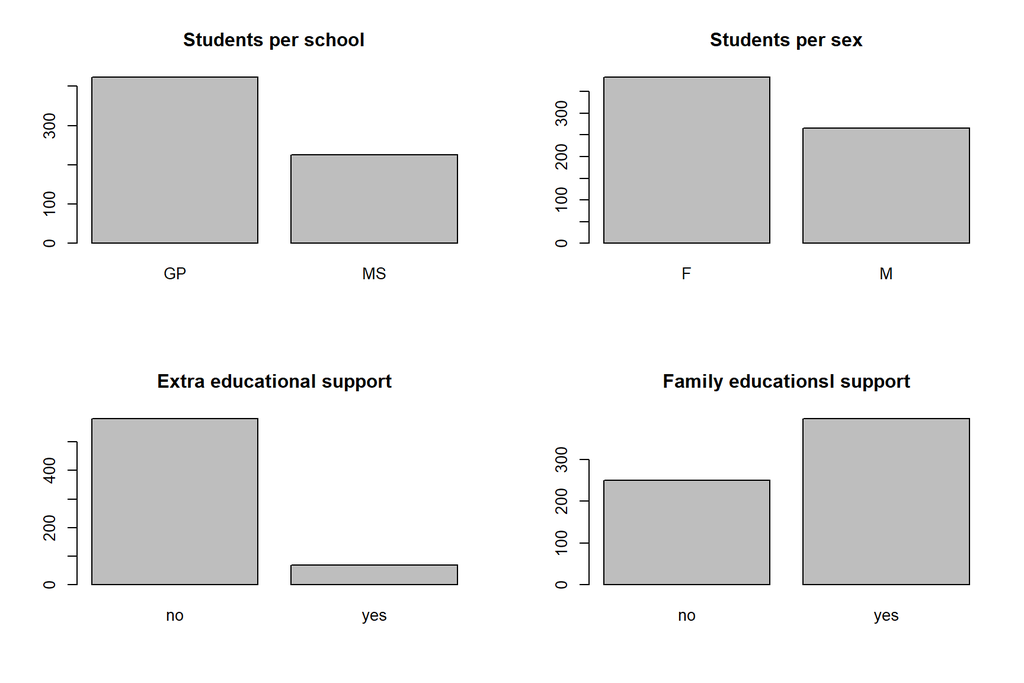

```r
par(mfrow=c(2,2))
barplot(table(student$school), main="Students per school")
barplot(table(student$sex), main="Students per sex")
barplot(table(student$schoolsup), main="Extra educational support")
barplot(table(student$famsup), main="Family educationsl support")
```

Moreover we will depict the students who passed and they who failed the course.

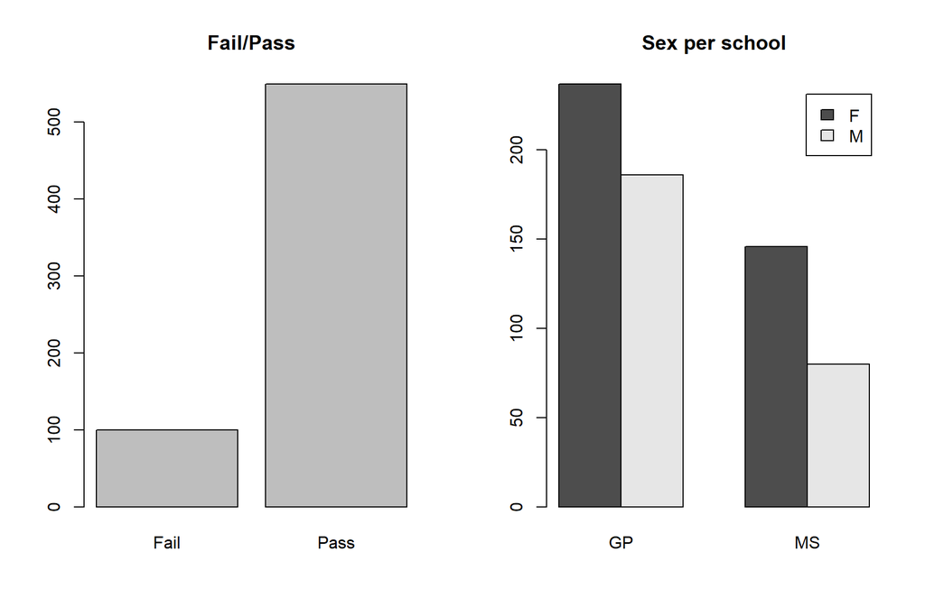

```r
par(mfrow=c(1,2))
barplot(table(grades$G3),main="Fail/Pass")
barplot(table(student$sex,student$school),beside=TRUE,legend=TRUE,main ="Sex per school")
```

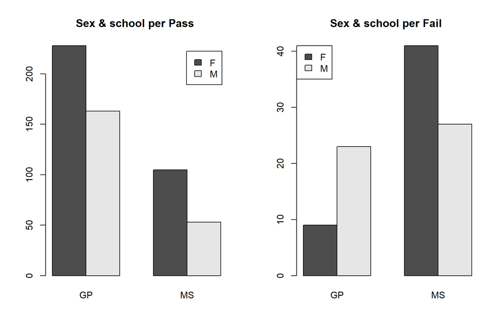

```r
barplot(table(stpass$sex,stpass$school),legend=TRUE,beside=TRUE,main="Sex & school per Pass ")
barplot(table(stfail$sex,stfail$school),legend=TRUE,beside=TRUE,args.legend = list(x="topleft") ,main="Sex & school per Fail ")
```

Now we will present two pie plots with the mother’s and father’s education.

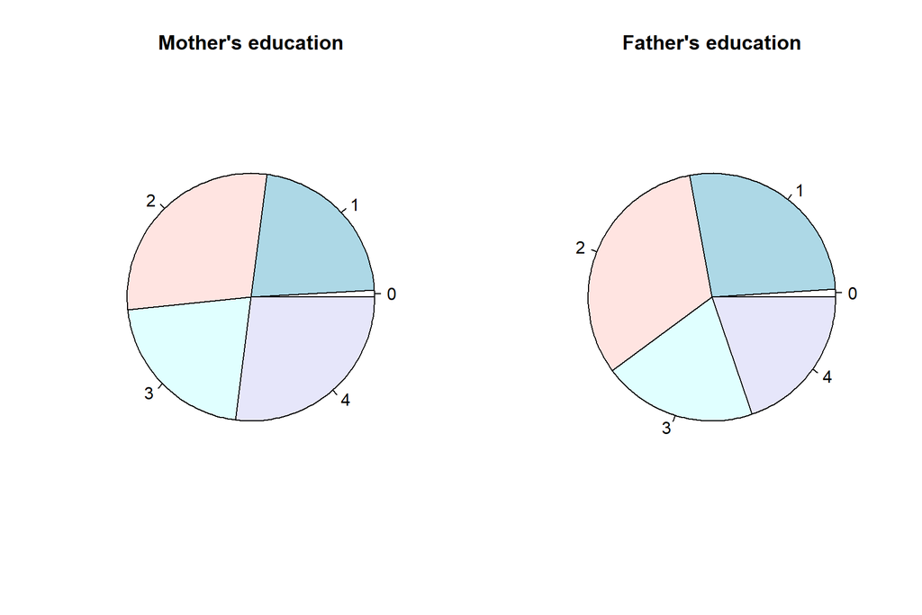

```r
par(mfrow=c(1,2))
pie(table(student$Medu),main="Mother's education")
pie(table(student$Fedu),main="Father's education")
```

There will be a boxplot for the outliers of our data set.

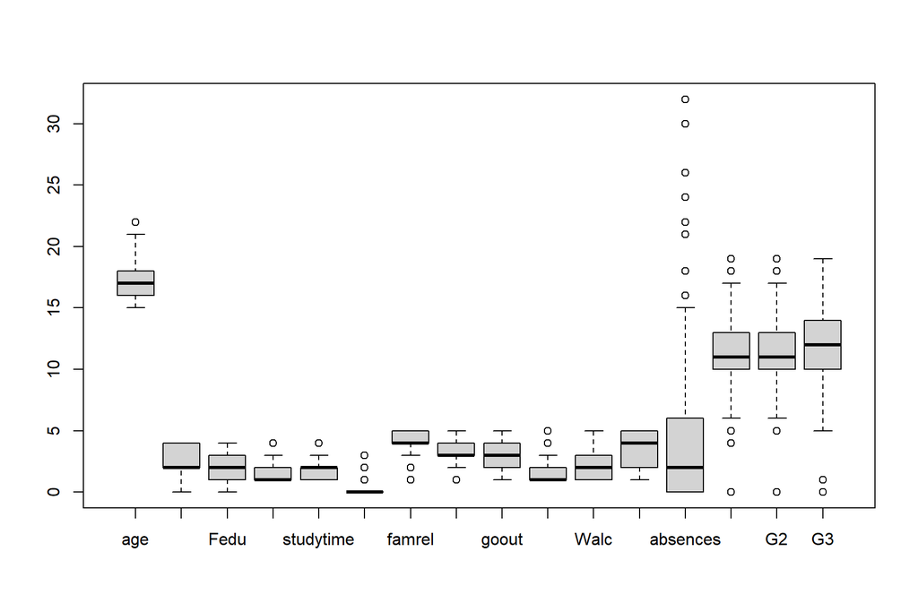

```r
numeric.only <- sapply(student,class)=='numeric'
data<-student
y <- data[,numeric.only]
n<-ncol(y)
boxplot(y)
```

### Pairwise Associations.

In this section we aim to find any correlation between the variables.

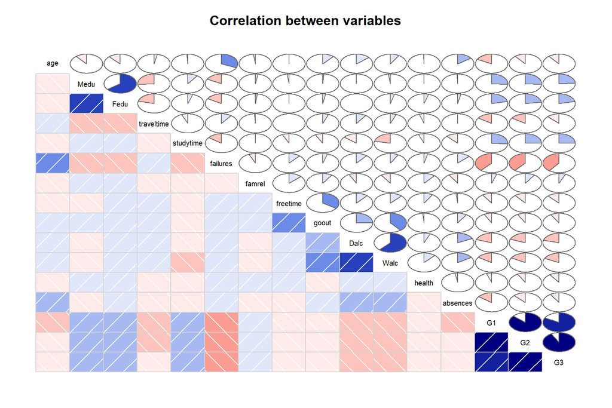

```r
library(corrgram)
corrgram(student,lower.panel=panel.shade,
  upper.panel=panel.pie, text.panel=panel.txt,main="Correlation between variables")
```

#### Q-Q plots

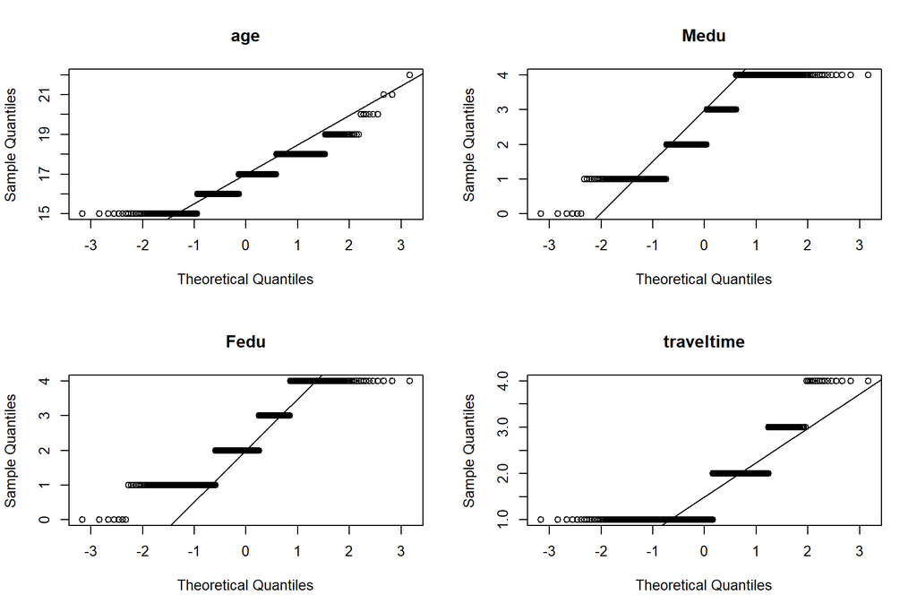

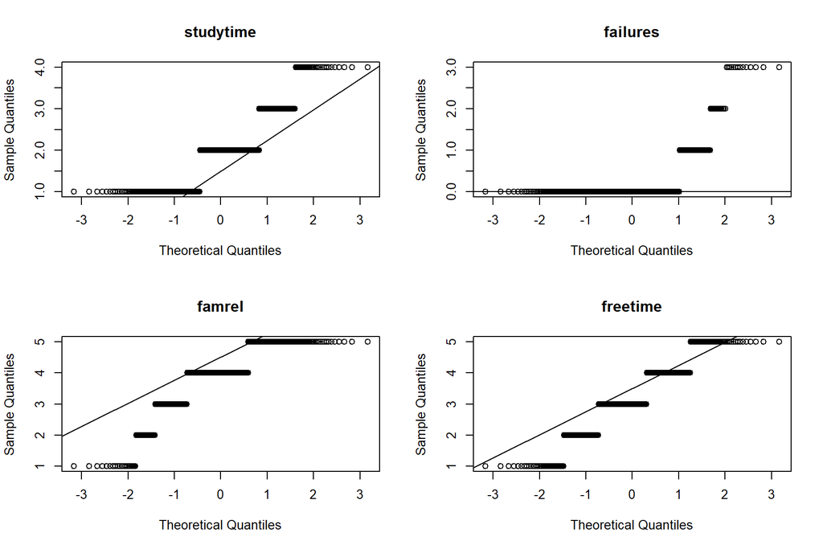

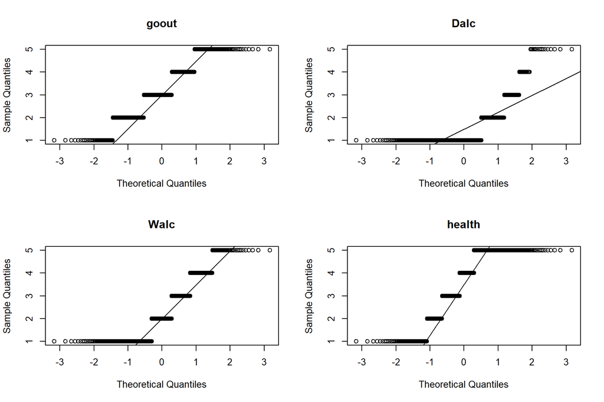

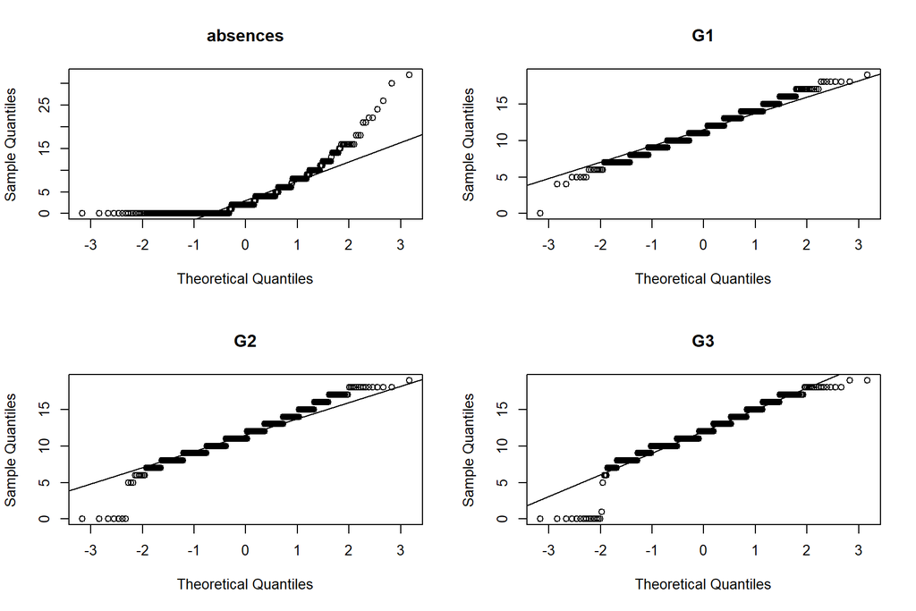

```r
p<-ncol(y)
par(mfrow=c(2,2))
for (i in 1:p){
  qqnorm(y[,i],main=names(y)[i])
  qqline(y[,i])
}
```

#### Saphiro test for normality

The Shapiro–Wilk test tests the null hypothesis that a sample $x_1,x_2,...,x_n$ came from a normally distributed population. The test statistic is
$$W=\frac{(\sum_{i=1}^na_ix_{(i)})^2}{\sum_{i=1}^n(x_i-\bar{x})^2}$$
It is important not to confused the $x_{(i)}$ which the ith-smallest number in the sample with the $x_i$ which is the ith observe of the sample.

```r
for (i in 1:length(y)){
  print(shapiro.test(y[,i]))
}
```

```
##
##  Shapiro-Wilk normality test
##
## data:  y[, i]
## W = 0.91559, p-value < 2.2e-16
##
##
##  Shapiro-Wilk normality test
##
## data:  y[, i]
## W = 0.86971, p-value < 2.2e-16
##
##
##  Shapiro-Wilk normality test
##
## data:  y[, i]
## W = 0.87506, p-value < 2.2e-16
##
##
##  Shapiro-Wilk normality test
##
## data:  y[, i]
## W = 0.72488, p-value < 2.2e-16
##
##
##  Shapiro-Wilk normality test
##
## data:  y[, i]
## W = 0.82508, p-value < 2.2e-16
##
##
##  Shapiro-Wilk normality test
##
## data:  y[, i]
## W = 0.42355, p-value < 2.2e-16
##
##
##  Shapiro-Wilk normality test
##
## data:  y[, i]
```

[output cut: 40 more lines]

```
##
## data:  y[, i]
## W = 0.98554, p-value = 4.934e-06
##
##
##  Shapiro-Wilk normality test
##
## data:  y[, i]
## W = 0.96167, p-value = 5.583e-12
##
##
##  Shapiro-Wilk normality test
##
## data:  y[, i]
## W = 0.92598, p-value < 2.2e-16
```

By the q-q plots and Saphiro-Wilk test we can not assume normality.

#### Skewness and Kurtosis

Formula for skewness:
$$γ_1=\frac{\frac{1}{n}\sum_{i=1}^n(x_i-\bar{x})^3}{(\frac{1}{n}\sum_{i=1}^n(x_i-\bar{x})^2)^{3/2}}$$
$\bullet$ If the coefficient of skewness is greater than 0 , then the graph is said to be positively skewed with the majority of data values less than mean. Most of the values are concentrated on the left side of the graph.
$\bullet$ If the coefficient of skewness is equal to 0 or approximately close to 0 , then the graph is said to be symmetric and data is normally distributed.
$\bullet$ If the coefficient of skewness is less than 0 ,then the graph is said to be negatively skewed with the majority of data values greater than mean. Most of the values are concentrated on the right side of the graph.

```r
library(moments)
skewness(y)
```

```
##          age         Medu         Fedu   traveltime    studytime     failures
##  0.415831443 -0.029881091  0.214845331  1.244762073  0.698001173  3.085546372
##       famrel     freetime        goout         Dalc         Walc       health
## -1.103376360 -0.180858233 -0.008560061  2.136959686  0.634433593 -0.499498304
##     absences           G1           G2           G3
##  2.016020378 -0.002767222 -0.359449409 -0.910798039
```

Formula for
$$γ_2=\frac{\frac{1}{n}\sum_{i=1}^n(x_i-\bar{x})^4}{(\frac{1}{n}\sum_{i=1}^n(x_i-\bar{x})^2)^2}$$
There exist 3 types of Kurtosis values on the basis of which sharpness of the peak is measured.
$\bullet$ Platykurtic.If the coefficient of kurtosis is less than 3 i.e. $\gamma_{2}<3$, then the data distribution is platykurtic. Being platykurtic doesn’t mean that the graph is flat-topped.
$\bullet$ Mesorkurtic.If the coefficient of kurtosis is equal to 3 or approximately close to 3 i.e. $\gamma_{2}=3$, then the data distribution is mesokurtic. For normal distribution, kurtosis value is approximately equal to 3.
$\bullet$ Leptokurtic.If the coefficient of kurtosis is greater than 3 i.e. $\gamma_{2}>3$, then the data distribution is leptokurtic and shows a sharp peak on the graph.

```r
kurtosis(y)
```

```
##        age       Medu       Fedu traveltime  studytime   failures     famrel
##   3.061728   1.739841   1.890055   4.091110   3.028324  12.739652   4.329372
##   freetime      goout       Dalc       Walc     health   absences         G1
##   2.596862   2.131969   7.306631   2.226005   1.878213   8.727404   3.027126
##         G2         G3
##   4.640454   5.682123
```

### Regression Models.

In this part, we are going to fit some regression models in order to understand better which variables are most important in extracting the final grade. It’s known that the variables **G1**,**G2** and **G3** are highly correlated as **G1** and **G2** correspond to the first and second period grades. It is more difficult to predict **G3** without taking into account **G2** and **G3**, but it is what we will try.  
First of all, we start with LASSO procedure and then we are going to do Stepwise procedure in order to fit our regression model.

#### LASSO regression

LASSO regression is a type of linear regression that uses shrinkage. The lasso process encourages simple models with fewer parameters. LASSO is based on the $l_1$ penalization.
$$minimize(\mathbf{y}-\mathbf{Z}β)^T(\mathbf{y}-\mathbf{Z}β)$$
$$s.t. \sum_{j=1}^p |β_j| \leq t$$
$$minimize\{(\mathbf{y}-\mathbf{Z}β)^T(\mathbf{y}-\mathbf{Z}β)+λ \sum_{j=1}^p |β_j|\}$$

#### LASSO for G1

```r
library(glmnet)
```

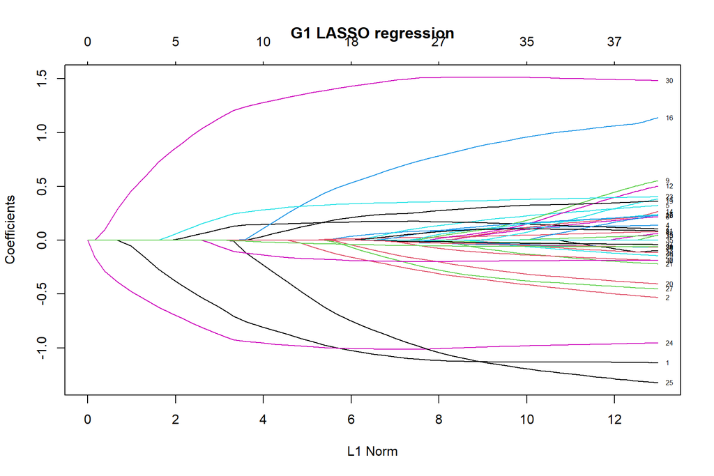

```r
mfull<-lm(student$G1~.-G2-G3,data=student)
X<-model.matrix(mfull)[,-1]
lasso1<-glmnet(X,student$G1)
plot(lasso1, label=TRUE, main="G1 LASSO regression")
```

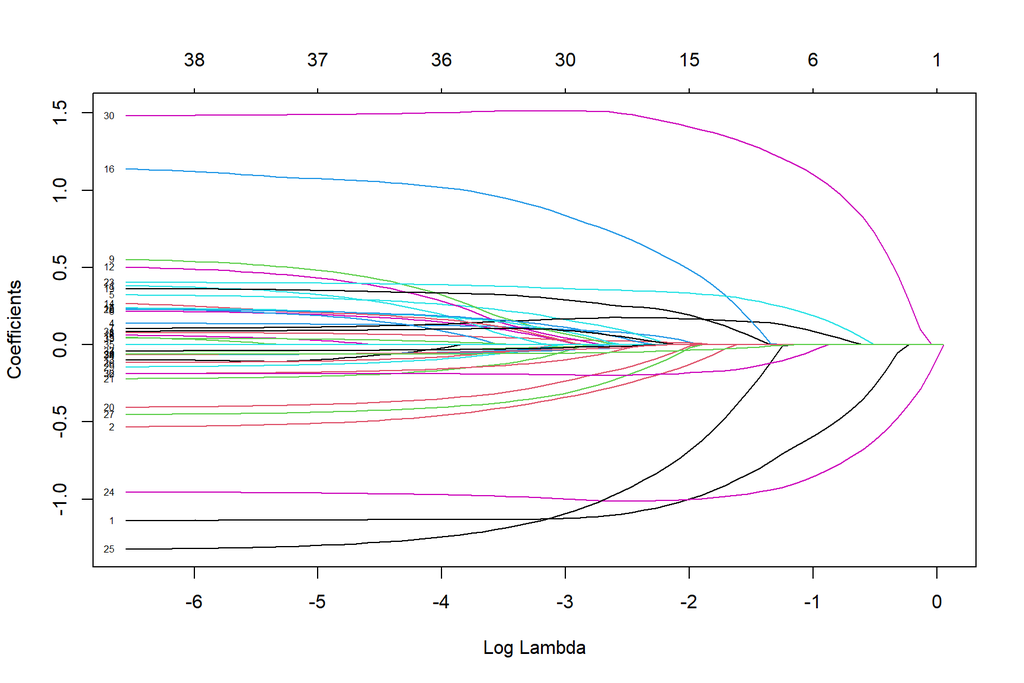

```r
plot(lasso1, xvar='lambda', label=TRUE, log)
```

Now, we are looking for the most appropriate λ:

```r
lasso2 <- cv.glmnet(X,student$G1)
l<-lasso2$lambda.min
l
```

```
## [1] 0.1130113
```

```r
lasso2$lambda.1se
```

```
## [1] 0.3144605
```

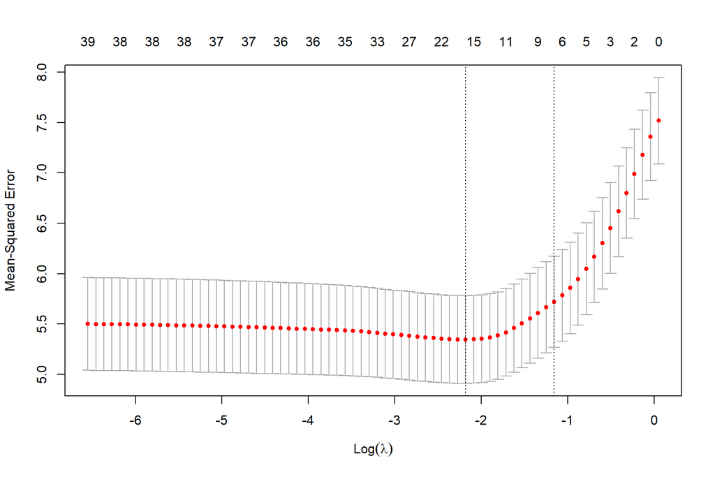

```r
plot(lasso2)
```

```r
blasso2<- coef(lasso2, s = "lambda.1se")
blasso2
```

```
## 40 x 1 sparse Matrix of class "dgCMatrix"
##                           s1
## (Intercept)      10.17318954
## schoolMS         -0.66190147
## sexM              .
## age               .
## addressU          .
## famsizeLE3        .
## PstatusT          .
## Medu              0.11624224
## Fedu              .
## Mjobhealth        .
## Mjobother         .
## Mjobservices      .
## Mjobteacher       .
## Fjobhealth        .
## Fjobother         .
## Fjobservices      .
## Fjobteacher       .
## reasonhome        .
## reasonother       .
## reasonreputation  .
## guardianmother    .
## guardianother     .
## traveltime        .
## studytime         0.22665164
## failures         -0.89981175
## schoolsupyes      .
## famsupyes         .
## paidyes           .
## activitiesyes     .
## nurseryyes        .
## higheryes         1.17302824
## internetyes       .
## romanticyes       .
## famrel            .
## freetime          .
## goout             .
## Dalc             -0.08132883
## Walc              .
## health            .
## absences          .
```

```r
print(lasso2)
```

```
##
## Call:  cv.glmnet(x = X, y = student$G1)
##
## Measure: Mean-Squared Error
##
##     Lambda Index Measure     SE Nonzero
## min 0.1130    25   5.345 0.4357      18
## 1se 0.3145    14   5.719 0.4531       6
```

#### Stepwise procedure for G1

```r
mfull<-lm(G1~.-G2-G3,data=student)
summary(step(mfull,direction = "both",k=log(100))) #BIC
```

```
## Start:  AIC=1199.68
## G1 ~ (school + sex + age + address + famsize + Pstatus + Medu +
##     Fedu + Mjob + Fjob + reason + guardian + traveltime + studytime +
##     failures + schoolsup + famsup + paid + activities + nursery +
##     higher + internet + romantic + famrel + freetime + goout +
##     Dalc + Walc + health + absences + G2 + G3) - G2 - G3
##
##              Df Sum of Sq    RSS    AIC
## - Mjob        4    11.885 3114.8 1183.7
## - reason      3    12.246 3115.2 1188.4
## - Fjob        4    35.596 3138.5 1188.7
## - guardian    2    17.381 3120.3 1194.1
## - goout       1     0.009 3102.9 1195.1
## - internet    1     0.657 3103.6 1195.2
## - Walc        1     0.904 3103.8 1195.3
## - famrel      1     0.952 3103.9 1195.3
## - traveltime  1     1.222 3104.2 1195.3
## - age         1     1.249 3104.2 1195.3
## - famsup      1     1.917 3104.9 1195.5
## - address     1     2.024 3105.0 1195.5
## - nursery     1     2.111 3105.1 1195.5
## - Fedu        1     2.423 3105.4 1195.6
## - freetime    1     2.636 3105.6 1195.6
## - Pstatus     1     2.940 3105.9 1195.7
## - Medu        1     3.236 3106.2 1195.8
## - romantic    1     4.889 3107.8 1196.1
## - health      1     4.933 3107.9 1196.1
## - paid        1     6.903 3109.8 1196.5
## - activities  1     7.723 3110.7 1196.7
## - Dalc        1    10.535 3113.5 1197.3
## - famsize     1    12.696 3115.6 1197.7
## <none>                    3102.9 1199.7
## - sex         1    32.817 3135.8 1201.9
## - absences    1    44.050 3147.0 1204.2
## - studytime   1    59.299 3162.2 1207.4
## - schoolsup   1    94.773 3197.7 1214.6
## - higher      1   106.257 3209.2 1216.9
## - school      1   128.597 3231.5 1221.4
## - failures    1   154.376 3257.3 1226.6
##
```

[output cut: 827 more lines]

```
## + famsup      1     0.804 3276.9 1096.9
## + age         1     0.639 3277.1 1097.0
## + goout       1     0.156 3277.6 1097.1
## + famrel      1     0.037 3277.7 1097.1
## - Dalc        1    47.517 3325.3 1097.2
## - absences    1    47.793 3325.5 1097.3
## - Medu        1    48.287 3326.0 1097.4
## + reason      3    20.937 3256.8 1102.1
## - studytime   1    83.044 3360.8 1104.1
## + Fjob        4    34.028 3243.7 1104.1
## - schoolsup   1    84.370 3362.1 1104.4
## + Mjob        4    12.370 3265.4 1108.5
## - higher      1   133.266 3411.0 1113.8
## - school      1   210.612 3488.4 1128.3
## - failures    1   248.147 3525.9 1135.2
```

```
##
## Call:
## lm(formula = G1 ~ school + Medu + studytime + failures + schoolsup +
##     higher + Dalc + absences, data = student)
##
## Residuals:
##      Min       1Q   Median       3Q      Max
## -11.7345  -1.5451  -0.1797   1.5666   7.4259
##
## Coefficients:
##              Estimate Std. Error t value Pr(>|t|)
## (Intercept)   9.95537    0.45889  21.694  < 2e-16 ***
## schoolMS     -1.28855    0.20094  -6.413 2.78e-10 ***
## Medu          0.25549    0.08321   3.071  0.00223 **
## studytime     0.44978    0.11170   4.027 6.33e-05 ***
## failures     -1.11663    0.16042  -6.961 8.40e-12 ***
## schoolsupyes -1.19838    0.29526  -4.059 5.54e-05 ***
## higheryes     1.60411    0.31446   5.101 4.46e-07 ***
## Dalc         -0.30163    0.09903  -3.046  0.00241 **
## absences     -0.06163    0.02018  -3.055  0.00235 **
## ---
## Signif. codes:  0 '***' 0.001 '**' 0.01 '*' 0.05 '.' 0.1 ' ' 1
##
## Residual standard error: 2.263 on 640 degrees of freedom
## Multiple R-squared:  0.3288, Adjusted R-squared:  0.3204
## F-statistic:  39.2 on 8 and 640 DF,  p-value: < 2.2e-16
```

```r
mfull<-lm(G1~.-G2-G3,data=student)
summary(step(mfull,direction = "both")) #AIC
```

```
## Start:  AIC=1095.47
## G1 ~ (school + sex + age + address + famsize + Pstatus + Medu +
##     Fedu + Mjob + Fjob + reason + guardian + traveltime + studytime +
##     failures + schoolsup + famsup + paid + activities + nursery +
##     higher + internet + romantic + famrel + freetime + goout +
##     Dalc + Walc + health + absences + G2 + G3) - G2 - G3
##
##              Df Sum of Sq    RSS    AIC
## - Mjob        4    11.885 3114.8 1090.0
## - reason      3    12.246 3115.2 1092.0
## - goout       1     0.009 3102.9 1093.5
## - internet    1     0.657 3103.6 1093.6
## - Walc        1     0.904 3103.8 1093.7
## - famrel      1     0.952 3103.9 1093.7
## - traveltime  1     1.222 3104.2 1093.7
## - age         1     1.249 3104.2 1093.7
## - famsup      1     1.917 3104.9 1093.9
## - address     1     2.024 3105.0 1093.9
## - nursery     1     2.111 3105.1 1093.9
## - Fedu        1     2.423 3105.4 1094.0
## - freetime    1     2.636 3105.6 1094.0
## - Pstatus     1     2.940 3105.9 1094.1
## - Medu        1     3.236 3106.2 1094.2
## - romantic    1     4.889 3107.8 1094.5
## - health      1     4.933 3107.9 1094.5
## - Fjob        4    35.596 3138.5 1094.9
## - paid        1     6.903 3109.8 1094.9
## - activities  1     7.723 3110.7 1095.1
## - guardian    2    17.381 3120.3 1095.1
## <none>                    3102.9 1095.5
## - Dalc        1    10.535 3113.5 1095.7
## - famsize     1    12.696 3115.6 1096.1
## - sex         1    32.817 3135.8 1100.3
## - absences    1    44.050 3147.0 1102.6
## - studytime   1    59.299 3162.2 1105.8
## - schoolsup   1    94.773 3197.7 1113.0
## - higher      1   106.257 3209.2 1115.3
## - school      1   128.597 3231.5 1119.8
## - failures    1   154.376 3257.3 1125.0
##
```

[output cut: 717 more lines]

```
## + age         1     0.698 3214.4 1066.4
## + Pstatus     1     0.421 3214.7 1066.4
## + famrel      1     0.106 3215.0 1066.5
## + goout       1     0.061 3215.1 1066.5
## + reason      3    19.010 3196.1 1066.7
## - sex         1    23.202 3238.3 1067.2
## - Dalc        1    29.453 3244.6 1068.4
## + Mjob        4    14.476 3200.7 1069.6
## - absences    1    49.555 3264.7 1072.5
## - studytime   1    62.402 3277.5 1075.0
## - Medu        1    64.824 3280.0 1075.5
## - schoolsup   1    93.462 3308.6 1081.1
## - higher      1   131.361 3346.5 1088.5
## - failures    1   210.395 3425.5 1103.7
## - school      1   230.193 3445.3 1107.4
```

```
##
## Call:
## lm(formula = G1 ~ school + sex + Medu + guardian + studytime +
##     failures + schoolsup + paid + higher + Dalc + absences, data = student)
##
## Residuals:
##      Min       1Q   Median       3Q      Max
## -11.8069  -1.4441  -0.1111   1.4554   7.0570
##
## Coefficients:
##                Estimate Std. Error t value Pr(>|t|)
## (Intercept)    10.45137    0.49249  21.222  < 2e-16 ***
## schoolMS       -1.36205    0.20184  -6.748 3.38e-11 ***
## sexM           -0.41934    0.19574  -2.142 0.032542 *
## Medu            0.30106    0.08407   3.581 0.000368 ***
## guardianmother -0.47680    0.21269  -2.242 0.025321 *
## guardianother  -0.41591    0.41707  -0.997 0.319031
## studytime       0.39846    0.11341   3.513 0.000474 ***
## failures       -1.05134    0.16297  -6.451 2.20e-10 ***
## schoolsupyes   -1.27203    0.29584  -4.300 1.98e-05 ***
## paidyes        -0.58209    0.37835  -1.538 0.124426
## higheryes       1.60530    0.31492   5.098 4.54e-07 ***
## Dalc           -0.24803    0.10276  -2.414 0.016071 *
## absences       -0.06350    0.02028  -3.131 0.001822 **
## ---
## Signif. codes:  0 '***' 0.001 '**' 0.01 '*' 0.05 '.' 0.1 ' ' 1
##
## Residual standard error: 2.248 on 636 degrees of freedom
## Multiple R-squared:  0.3417, Adjusted R-squared:  0.3292
## F-statistic:  27.5 on 12 and 636 DF,  p-value: < 2.2e-16
```

#### Backward procedure for G1

```r
mfull<-lm(G1~.-G2-G3,data=student)
summary(step(mfull,direction = "back",k=log(100))) #BIC
```

```
## Start:  AIC=1199.68
## G1 ~ (school + sex + age + address + famsize + Pstatus + Medu +
##     Fedu + Mjob + Fjob + reason + guardian + traveltime + studytime +
##     failures + schoolsup + famsup + paid + activities + nursery +
##     higher + internet + romantic + famrel + freetime + goout +
##     Dalc + Walc + health + absences + G2 + G3) - G2 - G3
##
##              Df Sum of Sq    RSS    AIC
## - Mjob        4    11.885 3114.8 1183.7
## - reason      3    12.246 3115.2 1188.4
## - Fjob        4    35.596 3138.5 1188.7
## - guardian    2    17.381 3120.3 1194.1
## - goout       1     0.009 3102.9 1195.1
## - internet    1     0.657 3103.6 1195.2
## - Walc        1     0.904 3103.8 1195.3
## - famrel      1     0.952 3103.9 1195.3
## - traveltime  1     1.222 3104.2 1195.3
## - age         1     1.249 3104.2 1195.3
## - famsup      1     1.917 3104.9 1195.5
## - address     1     2.024 3105.0 1195.5
## - nursery     1     2.111 3105.1 1195.5
## - Fedu        1     2.423 3105.4 1195.6
## - freetime    1     2.636 3105.6 1195.6
## - Pstatus     1     2.940 3105.9 1195.7
## - Medu        1     3.236 3106.2 1195.8
## - romantic    1     4.889 3107.8 1196.1
## - health      1     4.933 3107.9 1196.1
## - paid        1     6.903 3109.8 1196.5
## - activities  1     7.723 3110.7 1196.7
## - Dalc        1    10.535 3113.5 1197.3
## - famsize     1    12.696 3115.6 1197.7
## <none>                    3102.9 1199.7
## - sex         1    32.817 3135.8 1201.9
## - absences    1    44.050 3147.0 1204.2
## - studytime   1    59.299 3162.2 1207.4
## - schoolsup   1    94.773 3197.7 1214.6
## - higher      1   106.257 3209.2 1216.9
## - school      1   128.597 3231.5 1221.4
## - failures    1   154.376 3257.3 1226.6
##
```

[output cut: 574 more lines]

```
##
## Step:  AIC=1092.49
## G1 ~ school + Medu + studytime + failures + schoolsup + higher +
##     Dalc + absences
##
##             Df Sum of Sq    RSS    AIC
## <none>                   3277.7 1092.5
## - Dalc       1    47.517 3325.3 1097.2
## - absences   1    47.793 3325.5 1097.3
## - Medu       1    48.287 3326.0 1097.4
## - studytime  1    83.044 3360.8 1104.1
## - schoolsup  1    84.370 3362.1 1104.4
## - higher     1   133.266 3411.0 1113.8
## - school     1   210.612 3488.4 1128.3
## - failures   1   248.147 3525.9 1135.2
```

```
##
## Call:
## lm(formula = G1 ~ school + Medu + studytime + failures + schoolsup +
##     higher + Dalc + absences, data = student)
##
## Residuals:
##      Min       1Q   Median       3Q      Max
## -11.7345  -1.5451  -0.1797   1.5666   7.4259
##
## Coefficients:
##              Estimate Std. Error t value Pr(>|t|)
## (Intercept)   9.95537    0.45889  21.694  < 2e-16 ***
## schoolMS     -1.28855    0.20094  -6.413 2.78e-10 ***
## Medu          0.25549    0.08321   3.071  0.00223 **
## studytime     0.44978    0.11170   4.027 6.33e-05 ***
## failures     -1.11663    0.16042  -6.961 8.40e-12 ***
## schoolsupyes -1.19838    0.29526  -4.059 5.54e-05 ***
## higheryes     1.60411    0.31446   5.101 4.46e-07 ***
## Dalc         -0.30163    0.09903  -3.046  0.00241 **
## absences     -0.06163    0.02018  -3.055  0.00235 **
## ---
## Signif. codes:  0 '***' 0.001 '**' 0.01 '*' 0.05 '.' 0.1 ' ' 1
##
## Residual standard error: 2.263 on 640 degrees of freedom
## Multiple R-squared:  0.3288, Adjusted R-squared:  0.3204
## F-statistic:  39.2 on 8 and 640 DF,  p-value: < 2.2e-16
```

#### FINAL G1

```r
m1<-lm(G1~school+Medu+studytime+failures+schoolsup+higher+Dalc+absences,data=student)
summary(m1)
```

```
##
## Call:
## lm(formula = G1 ~ school + Medu + studytime + failures + schoolsup +
##     higher + Dalc + absences, data = student)
##
## Residuals:
##      Min       1Q   Median       3Q      Max
## -11.7345  -1.5451  -0.1797   1.5666   7.4259
##
## Coefficients:
##              Estimate Std. Error t value Pr(>|t|)
## (Intercept)   9.95537    0.45889  21.694  < 2e-16 ***
## schoolMS     -1.28855    0.20094  -6.413 2.78e-10 ***
## Medu          0.25549    0.08321   3.071  0.00223 **
## studytime     0.44978    0.11170   4.027 6.33e-05 ***
## failures     -1.11663    0.16042  -6.961 8.40e-12 ***
## schoolsupyes -1.19838    0.29526  -4.059 5.54e-05 ***
## higheryes     1.60411    0.31446   5.101 4.46e-07 ***
## Dalc         -0.30163    0.09903  -3.046  0.00241 **
## absences     -0.06163    0.02018  -3.055  0.00235 **
## ---
## Signif. codes:  0 '***' 0.001 '**' 0.01 '*' 0.05 '.' 0.1 ' ' 1
##
## Residual standard error: 2.263 on 640 degrees of freedom
## Multiple R-squared:  0.3288, Adjusted R-squared:  0.3204
## F-statistic:  39.2 on 8 and 640 DF,  p-value: < 2.2e-16
```

```r
library(BAS)
bas.results<-bas.lm(G1~school+Medu+studytime+failures+schoolsup+higher+Dalc+absences,data=student,prior="BIC")
bas.results
```

```
##
## Call:
## bas.lm(formula = G1 ~ school + Medu + studytime + failures +
##     schoolsup + higher + Dalc + absences, data = student, prior = "BIC")
##
##
##  Marginal Posterior Inclusion Probabilities:
##    Intercept      schoolMS          Medu     studytime      failures
##       1.0000        1.0000        0.9704        0.9990        1.0000
## schoolsupyes     higheryes          Dalc      absences
##       0.9990        1.0000        0.9695        0.9714
```

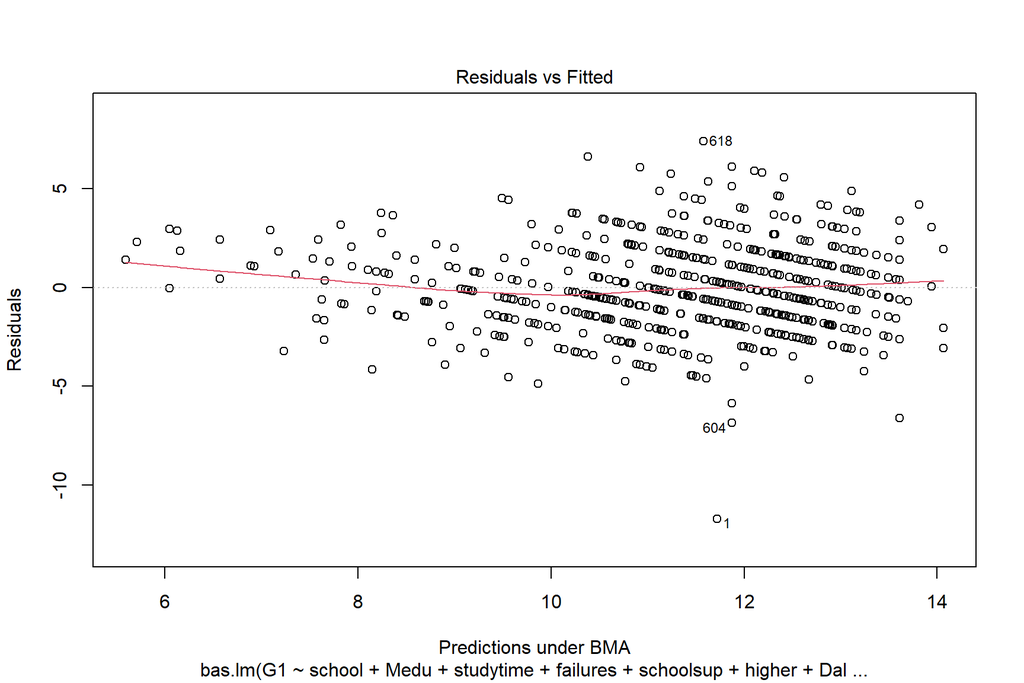

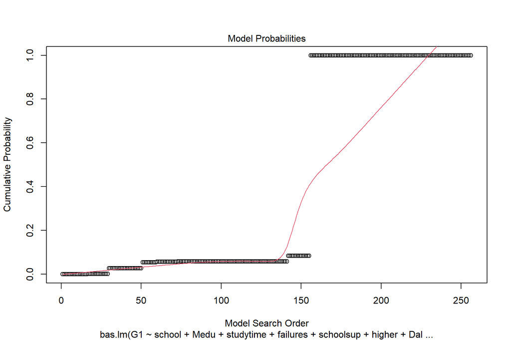

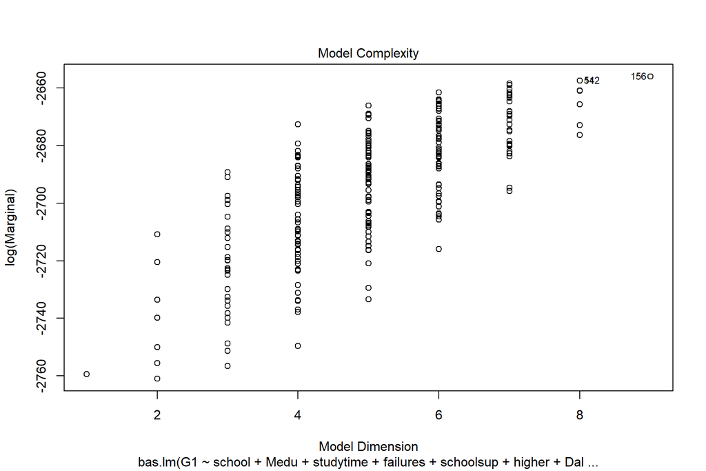

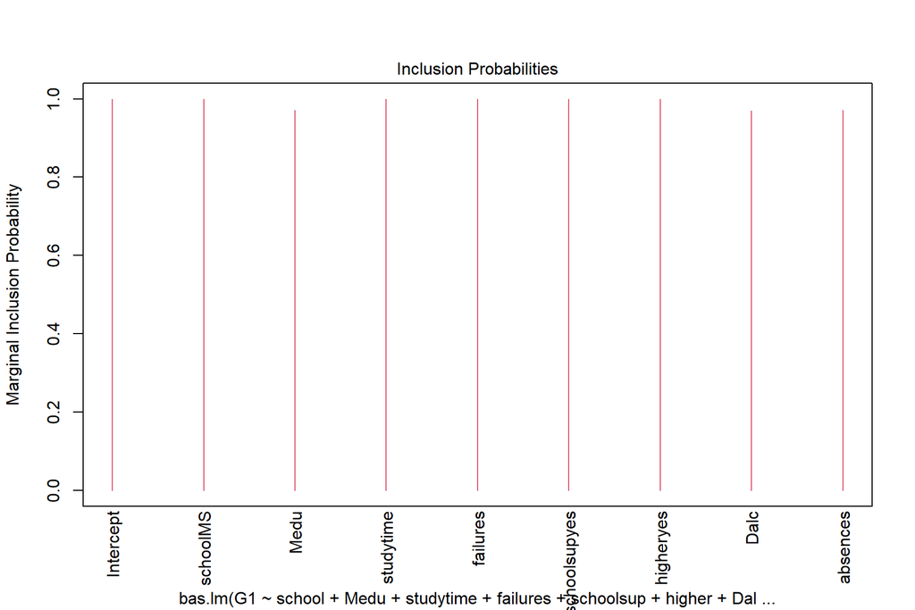

```r
plot(bas.results)
```

### LASSO for G2

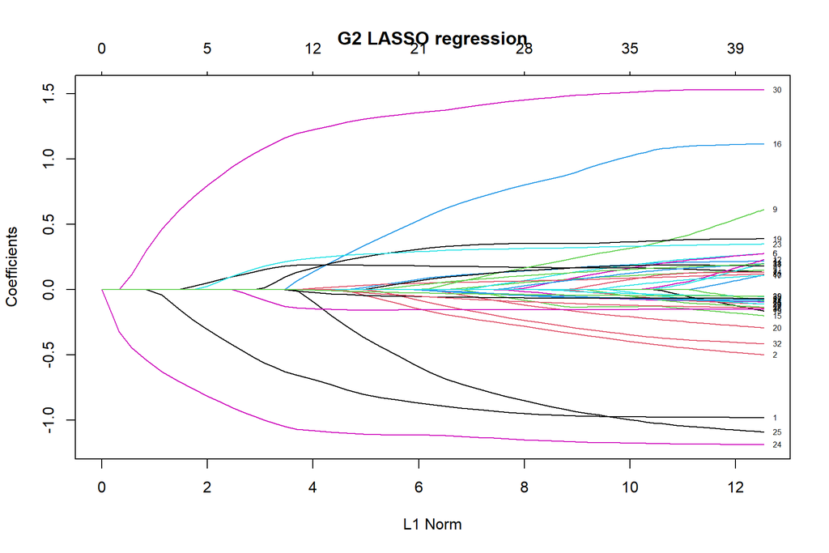

```r
mfull<-lm(student$G2~.-G1-G3,data=student)
X<-model.matrix(mfull)[,-1]
lasso1<-glmnet(X,student$G2)
plot(lasso1, label=TRUE, main="G2 LASSO regression")
```